# Ocean Acidification

Irais Luquis Ramos

2023-03-23

# Introduction

As a result of climate change, ocean acidification is altering the ocean’s carbon cycle.Increased CO2 absorption by the ocean is causing a significant decrease in seawater pH. [Doney et al. (2020)](https://www.annualreviews.org/doi/abs/10.1146/annurev.marine.010908.163834) Understanding the metabolic processes on the ocean ecosystem and the variability between net ecosystem production and net ecosystem calcification is key to understand how this changes will affect in the near future. [Meléndez et al. (2022)](https://aslopubs.onlinelibrary.wiley.com/doi/full/10.1002/lno.12009)

The Bermuda Institution of Ocean Science (BIOS) is a Bermuda-based research organization that has been collecting data for more than a century. Since its beginnings in 1988, the BATS program has continuously collected data on various oceanographic parameters. [BIOS](https://bios.edu)

**Load Required Library**

```r
library(tidyverse)
library(reader)
library(gsw)
library('seacarb')
library(performance)
```

**BATS Bottle Import Data**

```r
bats_bottle <- read_delim("bats_bottle.txt",
                          delim = "\t", escape_double = FALSE,
                          col_names = FALSE, trim_ws = TRUE, skip = 60)

colnames(bats_bottle)<- colnames(read_csv("bats_bottle.txt",
                                          skip = 59))
```

# Methods

Here we will be using The Gibbs SeaWater (GSW) Oceanographic Toolbox of TEOS-10 to helps us quantify ocean acidification over the past 30 years in the subtropical North Atlantic Ocean using BATS Time-series records. This with the intend to find different ways to predict changes going further into the future to help us understand what to expect in and analyze how this will affect the oceanic ecosystem.

**Can we quantify ocean acidification in the subtropical North Atlantic Ocean?**

1. Is surface ocean pCO2 increasing
2. Is surface ocean seawater pH decreasing?
3. Is surface ocean seawater saturation state with respect to aragonite decreasing?

Using the BATS data, we want to determine how these parameters (pCO2, pH, and aragonite) have change over time.

**Variables and Units**

- yyyymmdd = Year Month Day
- decy = Decimal Year
- time = Time (hhmm)
- latN = Latitude (Deg N)
- lonW = Longitude (Deg W)
- Depth = Depth (m)
- Temp = Temperature ITS-90 (C)
- CTD_S = CTD Salinity (PSS-78)
- Sal1 = Salinity-1 (PSS-78)
- Sig-th = Sigma-Theta (kg/m^3)
- O2(1) = Oxygen-1 (umol/kg)
- OxFixT = Oxygen Fix Temp (C)
- Anom1 = Oxy Anomaly-1 (umol/kg)
- CO2 = dissolved inorganic carbon (umol/kg)
- Alk = Alkalinity (uequiv)
- NO31 = Nitrate+Nitrite-1 (umol/kg)
- NO21 = Nitrite-1 (umol/kg)
- PO41 = Phosphate-1 (umol/kg)
- Si1 = Silicate-1 (umol/kg)
- POC = POC (ug/kg)
- PON = PON (ug/kg)
- TOC = TOC (umol/kg)
- TN = TN (umol/kg)
- Bact = Bacteria enumeration (cells*10^8/kg)
- POP = POP (umol/kg)
- TDP = Total dissolved Phosphorus (nmol/kg)
- SRP = Low-level phosphorus (nmol/kg)
- BSi = Particulate biogenic silica (umol/kg)
- LSi = Particulate lithogenic silica (umol/kg)
- Pro = Prochlorococcus (cells/ml)
- Syn = Synechococcus (cells/ml)
- Piceu = Picoeukaryotes (cells/ml)
- Naneu = Nanoeukaryotes (cells/ml)

**Quality flags**

- -999 = Missing or bad data
- 0 = Less than detection limit

**Calculate CO2 Chemistry Parameter**

We need to use the formula from ?carb;

- carb(flag, var1, var2, S=35, T=25, Patm=1, P=0, Pt=0, Sit=0, k1k2=“x”, kf=“x”, ks=“d”, pHscale=“T”, b=“u74”, gas=“potential”, warn=“y”, eos=“eos80”, long=1.e20, lat=1.e20)

Using the data we have TA, DIC (CO2), S, T, Pt, Sit, but we don’t have pressure (dbar).

Firts we need to calculate pressure using TEOS-10 with ?gsw and the formula p = gsw_p_from_z(z,lat)

```r
bats_co2=bats_bottle %>%
  mutate(P_dbar=gsw_p_from_z(Depth*-1,latN))

#We used -1 cause is negative in the ocean
```

We now have all of the variables that we need to calculate the surface seawater chemistry at the BATS station, but we need to be careful about using the same units as the parameter of the seawater carbonate system.

Now that we have TA, DIC, S, T, Pt, Sit, Pressure we need our BATS data units to be the same as the units used in the CO2sys.

- TA is in uequiv = umol/kg and we need mol/kg
  - Alk*10^-6
- DIC is in umol/ kg and we need mol/kg
  - DIC*10^-6
- S is in PSS and we will use Eos80
  - Sal1
- T is in degrees C and we need degree C
  - Temp
- Pt is in umol/kg and we need mol/kg
  - PO41*10^-6
- Sit is in umol/kg an we need mol/kg
  - Si1*10^-6
- P_dbar is in dbar and we need bar
  - P_dbar/10 or P_dbar*10^-1

We will need to convert Units scaling when using CO2sys. We copy the code from ?carb. Since we have we have TA y DIC we should use flag = 15 ALK and DIC.

**Units Scaling for CO2sys**

```r
bats_co2sys=
  bats_co2 %>%
  filter(Alk!=-999,CO2!=-999,Sal1!=-999,Temp!=-999,
         P_dbar!=-999,PO41!=-999,Si1!=-999,
         lonW!=-999,latN!=-999)%>%
  rename(DIC=CO2) %>%
  mutate(carb(flag=15, var1=Alk*10^-6, var2=DIC*10^-6,
              S=Sal1, T=Temp, Patm=1, P=P_dbar*10^-1,
              Pt=PO41*10^-6, Sit=Si1*10^-6,
              k1k2="l", kf="pf", ks="d", pHscale="T",
              b="u74", gas="potential",
              warn="y", eos="eos80",long=360-lonW, lat=latN))
#Create a new variable called bats_co2sys using the data of bats_co2 and use pipping to filter the missing or bad data of the variables. The variable DIC is converted to CO2 here using rename. And mutate of carb was use to calculate the co2sys parameters. Using this we got the parameter that we need to answer the questions (pCO2, pH, and aragonite)

bats_co2sys_surf = bats_co2sys %>%
  filter(Depth<100) %>%
  filter(pCO2insitu>100)
#Here it filters to a depth<100 selecting only the upper 100m meaning we are working in surface water. And filter pCO2 to not include pCO2insitu>100
```

# Questions

**1) Is surface ocean pco2 increasing**

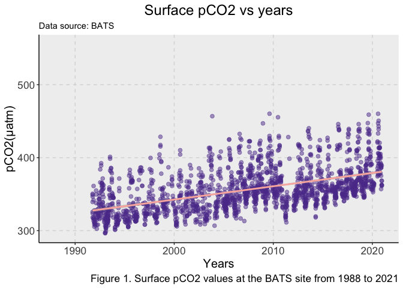

```r
bats_co2sys_surf %>%
  ggplot(mapping = aes(x=decy, y=pCO2insitu))+
  geom_point(color = "#5e3c99",size=2,alpha=0.5)+
  geom_smooth(method="lm",size=1.0,color="#fbb4ae")+
  scale_x_continuous(limits=c(1988,2021))+
  labs(x="Years",y="pCO2(µatm)",title="Surface pCO2 vs years",
       subtitle="Data source: BATS")+
  theme_classic()+
  theme(plot.title=element_text(hjust=0.5,size=18),
        axis.title=element_text(size=15),
        axis.text=element_text(size=13),
        plot.caption=element_text(size=13))+
  theme(panel.grid.major=element_line(color="#d9d9d9",linetype="dashed"),
        panel.grid.minor=element_blank(),
        panel.background=element_rect(fill="#f0f0f0"))+
  labs(caption="Figure 1. Surface pCO2 values at the BATS site from 1988 to 2021")
```

```r
check=bats_co2sys_surf%>%
  filter(pCO2<200) #Filter for only pCO2 less than 200; meaning we are working with parameter measurements on the surface

pCO2_model = lm(pCO2insitu~decy, data=bats_co2sys_surf)
#Linear regression between surface pCO2 and the years to determine if it is increasing or decreasing
```

**Checking model performance**

```r
#This is used to confirm assumptions about the model
#check_model(pCO2_model)

#The summary is using ANOVA to produce the p-values. (p-values are the same)
summary(pCO2_model) #the summary of the lineal regression
```

```
##
## Call:
## lm(formula = pCO2insitu ~ decy, data = bats_co2sys_surf)
##
## Residuals:
##     Min      1Q  Median      3Q     Max
## -52.302 -18.081  -7.098  12.657 173.045
##
## Coefficients:
##               Estimate Std. Error t value Pr(>|t|)
## (Intercept) -3.396e+03  1.328e+02  -25.57   <2e-16 ***
## decy         1.869e+00  6.616e-02   28.25   <2e-16 ***
## ---
## Signif. codes:  0 '***' 0.001 '**' 0.01 '*' 0.05 '.' 0.1 ' ' 1
##
## Residual standard error: 25.75 on 1937 degrees of freedom
## Multiple R-squared:  0.2919, Adjusted R-squared:  0.2915
## F-statistic: 798.3 on 1 and 1937 DF,  p-value: < 2.2e-16
```

```r
anova(pCO2_model)
```

```
## Analysis of Variance Table
##
## Response: pCO2insitu
##             Df  Sum Sq Mean Sq F value    Pr(>F)
## decy         1  529187  529187  798.33 < 2.2e-16 ***
## Residuals 1937 1283970     663
## ---
## Signif. codes:  0 '***' 0.001 '**' 0.01 '*' 0.05 '.' 0.1 ' ' 1
```

**Ploting model prediction**

We could use the tidy way with dplyr were the outputs will need to be rename or the base R method were the outputs do not need to be rename.

```r
#We used ?predict

bats_co2sys_surf_pred=
  bats_co2sys_surf %>%
  mutate(predict(pCO2_model,interval='confidence',level=0.95))

bats_co2sys_surf_pred=
  cbind(bats_co2sys_surf, predict(pCO2_model,interval = 'confidence',level=0.95))

#Adding the prediction line of pCO2_model to ggplot
#This predictions could be used to merge the bats_co2sys_surf with the bats_co2sys_surf_pred. We can make with this a two variable plot with the prediction model giving a shaded region of 95% of confidence around the model line.
```